# functional_programming slides

### Stop playing with your `self`

#### An introduction to functional programming in Python

Zoe Gadon

Software engineer at Exizent

@gingerzoealex

### What actually is "Functional Programming"?

> In computer science, functional programming is a programming paradigm where programs are constructed by applying and composing functions. ... When a pure function is called with some given arguments, it will always return the same result, and cannot be affected by any mutable state or other side effects.

So....

- All variables are constant
- Imperative vs declarative

### What are we going to do tonight, Brain?

- First class functions
- Higher order functions
- map()
- filter()
- reduce()
- lambdas λ
- list comprehension
- lists of functions?!
- (probably not) recursion
- (probably definitely not) partial application

Watch out for:

- un-indent-ional mistakes ;)
- immutability. Variables can't change, functions return or modify copies

### OOP vs Functional

... not a fight, just an example

[figure not shown]

```python
class Pizza:
    size = '16"'
    def add_sauce(self, sauce):
        self.sauce = sauce

    def add_toppings(self, toppings):
        self.toppings = toppings


nom = Pizza()
nom.add_sauce("tomato")
nom.add_toppings("sweetcorn, peppers")
print(nom.size)
print(nom.sauce)
print(nom.toppings)
```

```
16"
tomato
sweetcorn, peppers
```

[figure not shown]

```python
pizza_1 = {
    "sauce": "tomato",
    "toppings": "cheese",
    "size": "12"
}

pizza_2 = {
    "sauce": "bbq",
    "toppings": "pineapple",
    "size": "9"
}

pizza_menu = [ pizza_1, pizza_2 ]

def get_pizzas(pizza_menu):
    # imagine there's more logic here :)
    return [pizza for pizza in pizza_menu]
```

```python
pizzas = get_pizzas(pizza_menu)

print(pizzas)
```

```
[{'sauce': 'tomato', 'toppings': 'cheese', 'size': '12'}, {'sauce': 'bbq', 'toppings': 'pineapple', 'size': '9'}]
```

You can interact with the data without having to mutate the pizzas

### First class functions?

It means functions are treated like "first class citizens".

...so they're important?

-> can be passed around and changed

-> can be treated like other data types

-> can be stored in variables and/or data structures

-> is an instance of the Object type

-> can be returned from functions

```python
def shout(text):
    return text.upper()

print(shout("Hello Pythoners"))
```

```
HELLO PYTHONERS
```

```python
yell = shout

print(yell("hello"))
```

```
HELLO
```

`yell` and `shout` are functions

```python
print(yell)

print(shout)
```

```
<function shout at 0x7f158065c550>
<function shout at 0x7f158065c550>
```

What if we want a function to be called conditionally?

```python
TIME = "evening"

def make_spagetti():
    print("Time to make spagetti")
    return "spagetti"

def make_sandwich():
    print("Time to make a sandwich")
    return "Sandwich"
```

```python
make_food = make_spagetti if TIME == "evening" else make_sandwich

what_food_1 = make_food()
```

[output not shown]

If you change the environment variable value...

```python
TIME = "afternoon"
print(TIME)
what_food_2 = make_food()
```

[output not shown]

`make_food()` doesn't change in value

A more practical use case for this is when you want to run tests...

```python
ENVIRONMENT = "development"

def get_lots_of_real_data():
    return "Doing time consuming things."

def get_lots_of_fake_data():
    return "A useful test that doesn't do the time consuming things"

make_request = get_lots_of_real_data if ENVIRONMENT == "production" else get_lots_of_fake_data

data = make_request()
print(data)
```

```
A useful test that doesn't do the time consuming things
```

### Functions in lists

```python
def minus_one(x):
    return x - 1

def double(x):
    return x * 2

def square(x):
    return x * x
my_number = 3

my_number = double(my_number)
my_number = minus_one(my_number)
my_number = square(my_number)

print(my_number)
```

```
25
```

```python
function_list = [
  double,
  minus_one,
  square
]

my_number = 3

for func in function_list:
    thing = func(my_number)
    print(f"{func} = {thing}")
```

```
<function double at 0x7f1580f12e50> = 6
<function minus_one at 0x7f15805ddd30> = 2
<function square at 0x7f15805dd0d0> = 9
```

```python
def add(x, y):
    return x + y

def subtract(x, y):
    return x - y

def combine_2_and_3(func):
    return func(2, 3)

print(combine_2_and_3(min))
```

```
2
```

```python
print(combine_2_and_3(add))

print(combine_2_and_3(subtract))
```

```
5
-1
```

### Functions returning functions returning functions ....

Black box functions: functions in → functions out

A standard principle in programming - code goes in, code comes out.

In functional programming, functions go in, functions come out.

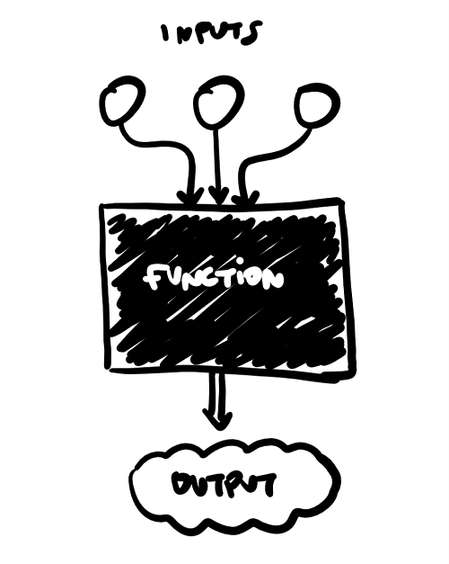

image credit: [thatsoftwaredude.com](https://www.thatsoftwaredude.com/content/8881/what-is-blackbox-code-and-why-its-important)

Limits scope - protects the function from being used in other places where it may not work

```python
def greeting():
    def hello():
        print("Hello!")
    return hello

greet = greeting()
greet()
```

```
Hello!
```

```python
error = hello()
print(error)
```

```
---------------------------------------------------------------------------
NameError                                 Traceback (most recent call last)
<ipython-input-199-fb05f916eb45> in <module>
----> 1 error = hello()
      2 print(error)

NameError: name 'hello' is not defined
```

`greeting()` is a black box, and there's no access to `hello()` from outside the function.

```python
def double(x):
  return x*2

def triple(x):
  return x*3

def quadruple(x):
  return x*4

print(double(1))
print(triple(2))
print(quadruple(3))
```

```
2
6
12
```

This code is being reused, let's refactor :)

```python
def create_multiplier(a):
  def multiplier(x):
   return x * a
  return multiplier

double = create_multiplier(2)
triple = create_multiplier(3)
quadruple = create_multiplier(4)

print(double(4))
print(triple(5))
print(quadruple(6))
```

```
8
15
24
```

It does the same thing, but `multiplier()` is hidden and limited to within the scope of `create_multiplier()`

Closure: no access to a function or variable other than through the outer function.

> A closure is a nested function which has access to a free variable from an enclosing function that has finished its execution. Three characteristics of a Python closure are:
> - it is a nested function
> - it has access to a free variable in outer scope
> - it is returned from the enclosing function

```python
def create_printer():
    my_favourite_number = 5
    def printer():
        print(f"my fav number is {my_favourite_number}")
    return printer

my_printer = create_printer()
my_printer() # <- has access to variable my_fav_num
```

```
my fav number is 5
```

```python
def create_counter():
    count = 0
    def get_count():
        return count
    def increment():
        nonlocal count
        count += 1
    return (get_count, increment)
```

[output not shown]

```python
get_count, increment = create_counter()

increment()
increment()
increment()
increment()
print(get_count())
```

```
4
```

## Higher order functions

Overlaps with the other concepts we've covered already.

Important part of what makes your Python functional.

### Properties of higher-order functions:

it can be stored in a variable or data structure

it can be passed into a function

it can receive a function in a parameter

it returns a function

it is the Object type

```python
def divide(x, y):
    return x / y

bad_division = divide(5, 0)
```

```
---------------------------------------------------------------------------
ZeroDivisionError                         Traceback (most recent call last)
<ipython-input-226-8fa868406549> in <module>
      2     return x / y
      3
----> 4 bad_division = divide(5, 0)

<ipython-input-226-8fa868406549> in divide(x, y)
      1 def divide(x, y):
----> 2     return x / y
      3
      4 bad_division = divide(5, 0)

ZeroDivisionError: division by zero
```

```python
def second_argument_isnt_zero(func):
    def safe_version(*args):
        if args[1] == 0:
            print("Warning: second argument is zero")
            return
        return func(*args)
    return safe_version

safe_division = second_argument_isnt_zero(divide)

print(safe_division(10, 5))
```

```
2.0
```

`second_argument_isnt_zero()` takes the `divide()` function as a parameter and ensures there's no divide by 0 exception.

`safe_division()` is called with the args for `divide()`, which returns the correct value

```python
print(safe_division(10, 0))
```

[output not shown]

If we try and divide by 0, it returns the error message.

### What functional functions does Python have natively?

[figure not shown]

- map()
- filter()
- lambdas
- list comprehension
- reduce()

```python
numbers = [ 0,1,2,3,4 ]

# the procedural way
doubled = []
for x in numbers:
    doubled.append(x * 2)
print(doubled)
```

```
[0, 2, 4, 6, 8]
```

```python
numbers = [ 5,6,7,8,9 ]

def double(x):
  return x*2

doubled_list = list(map(double, numbers))
print(doubled_list)
```

```
[10, 12, 14, 16, 18]
```

## Filtering

### The procedural way

```python
list_for_filtering = [ 1,2,3,4,5,6,7,8,9 ]

even_numbers = []

for number in list_for_filtering:
    if (number % 2 == 0):
        even_numbers.append(number)

print(even_numbers)
```

```
[2, 4, 6, 8]
```

### The functional way

```python
def is_even(x):
    return x % 2 == 0

even_numbers_functional = list(filter(is_even, numbers_list))

print(even_numbers_functional)
```

```
[0, 2, 4, 6, 8]
```

## Lambdas

Anonymous functions - one line unnamed functions that can be defined inside larger expressions

Returns a value without needing the `return` keyword

Only allowed to be one statement long

Can't use `if`, but can use the ternary operator

Need to be small and simple

`lambda x, y : x + y`

```python
numbers_list_for_lambda = [ 0,1,2,3,4,5,6,7,8,9 ]

add = lambda x, y : x + y
```

`add` takes 2 arguments, x & y

```python
print(add(2,3))
```

```
5
```

```python
doubled_numbers = list(map(lambda x: x * 2, numbers_list))
print(doubled_numbers)
```

[output not shown]

And you can return a lambda function from another function so it's reusable

```python
def create_multiplier(a):
    return lambda x: x * a

double = create_multiplier(2)

print(double(5))
```

```
10
```

## List comprehension

A readable way of transforming elements in a list

```python
numbers_list = [ 0,1,2,3,4,5,6,7,8,9 ]
doubled = [ x * 2 for x in numbers_list ]
print(doubled)
```

```
[0, 2, 4, 6, 8, 10, 12, 14, 16, 18]
```

This works the same as when we do something like `map(double, numbers_list)`

```python
evens = [ x for x in numbers_list if x % 2 == 0 ]
print(evens)
```

```
[0, 2, 4, 6, 8]
```

This would be the same as using something like `filter(is_even, numbers_list)`

## Reduce

- Maths thing: "folding" or "reduction"
- Reduces a list of items to a single or cumulative value

Starting value = `accumulator`

`reduce()` adds each element of the list to the initial value (the accumulator - optional and defaults to 0)

`1` -> starting value

`1 + 2 = 3` -> add second number in list

`3 + 3 = 6` -> add third number in list

`6 + 4 = 10` -> add fourth number in list

...

```python
list_to_reduce = [ 0,1,2,3,4,5,6,7,8,9 ]
```

```python
from functools import reduce

def get_sum(acc, x):
    print(f"Accumulator: {acc}")
    print(f"x: {x}")
    return acc + x

sum = reduce(get_sum, list_to_reduce)

print(f"Sum: {sum}")
```

```
Accumulator: 0
x: 1
Accumulator: 1
x: 2
Accumulator: 3
x: 3
Accumulator: 6
x: 4
Accumulator: 10
x: 5
Accumulator: 15
x: 6
Accumulator: 21
x: 7
Accumulator: 28
x: 8
Accumulator: 36
x: 9
Sum: 45
```

### Python's list functions

A quick example to show how we can combine the list functions we've already covered:

- map()
- filter()
- reduce()

```python
starting_list = [ 1, 2, 3, 4, 5, 6]
```

And we'll use the `double()` method created earlier on

```python
doubled_list = list(map(double, starting_list)) # cast to a list
print(doubled_list)
```

```
[2, 4, 6, 8, 10, 12]
```

Create a new function to find numbers greater than 5

```python
def greater_than_5(x):
    return x > 5
```

Pass `doubled_list` to this method using `filter()` to create a list of numbers greater than 5

```python
filtered_list = list(filter(greater_than_5, doubled_list))
print(filtered_list)
```

```
[6, 8, 10, 12]
```

`reduce()` will "fold" the list (using the `get_sum()` function from earlier) - acting kind of like a for loop iterating and adding the items in the list

```python
total_of_list = reduce(get_sum, filtered_list)
print(total_of_list)
```

[output not shown]

## More advanced concepts that I probably won't be able to explain?

## Recursion

When a function calls itself

Behaves like a for loop

[figure not shown]

Image credit: [geeksforgeeks.org](https://www.geeksforgeeks.org/recursion-in-python/)

```python
def count_up(x):
    count_up(x + 1)

count_up(0)
```

```
---------------------------------------------------------------------------
RecursionError                            Traceback (most recent call last)
<ipython-input-92-bcc392c7f2e9> in <module>
      2     count_up(x + 1)
      3
----> 4 count_up(0)

<ipython-input-92-bcc392c7f2e9> in count_up(x)
      1 def count_up(x):
----> 2     count_up(x + 1)
      3
      4 count_up(0)

... last 1 frames repeated, from the frame below ...

<ipython-input-92-bcc392c7f2e9> in count_up(x)
      1 def count_up(x):
----> 2     count_up(x + 1)
      3
      4 count_up(0)

RecursionError: maximum recursion depth exceeded
```

```python
def count_up(x, maximum):
    if x > maximum:
        print("Done!")
        return
    print(x)
    #count_up(x + 1) <- recures infinitely so you need a stop condition
    count_up(x + 1, maximum)

count_up(0, 10)
```

## Partial application

`total=sum(8)(7)(6)` <- this?

fix number of args - less args than original function

configure general functions into more specific ones

An quick example of partial application :)

We need to import pythons built in library

```python
from functools import partial
```

Create a function that takes 3 arguments and returns the sum

```python
def add(x, y, z):
    return x + y + z

print(add(1, 2, 3))
```

How do we refactor this to use partial application?

```python
def add_partial(x):
    def add_others(y, z):
        return x + y + z
    return add_others

add_5 = add_partial(5)

print(add_5(6, 7))
```

```python
def add_partial_2(x, y):
    def add_others(z):
        return x + y + z
    return add_others

add_5_and_6 = add_partial_2(5, 6)

print(add_5_and_6(7))
```

```
18
```

```python
def curry_add(x):
    def curry_add_inner(y):
        def curry_add_inner_2(z):
            return x + y + z
        return curry_add_inner_2
    return curry_add_inner
```

```python
add_5 = curry_add(5)
add_5_and_6 = add_5(6)
print(add_5_and_6(7))
print(curry_add(5)(6)(7))
add_5 = partial(add, 5)
print(add_5(6, 7))
```

```
18
18
```

[output not shown]

## tldr;

[figure not shown]

- Functional programming is cool
- OOP is also cool, and is probably more widely used
- Do what you need to for what you're doing
- Remember -> imperitative vs declarative

A couple of helpful resources:

https://www.geeksforgeeks.org/first-class-functions-python/ https://python.plainenglish.io/treat-functions-as-first-class-object-in-python-fde635eec951 https://www.geeksforgeeks.org/higher-order-functions-in-python/ https://realpython.com/python-reduce-function/ https://zetcode.com/all/#python https://book.pythontips.com/en/latest/map_filter.html https://www.freecodecamp.org/news/imperative-vs-declarative-programming-difference/

Challenges: https://gist.github.com/oskarkv/3168ea3f8d7530ccd94c97c19aafe266